# Assignment 6 - Solution - Statistics II, Hertie School

#### 1 - Partisan ties and resource allocation in Ghana [13 points in total]

Do constituencies in Ghana that elect MPs who are from the same party as the President (the ruling party) receive more electrification over the next four years? Use the dataset `GhanaRD.csv` to find out. Here is a short description of the data:

- *constit:* constituency
- *voteshare:* vote share of MP from ruling party in a constituency
- *treatment:* elected MP from from rulinng party
- *changeNL_1996_2000:* change in electrification from 1996 - 2000 measured using nightlight emissions
- *mean_1995:* electrification in 1995
1. Does it make sense to employ a sharp RD in this case? Provide a visual check and a brief interpretation of what you see! [2 pts]

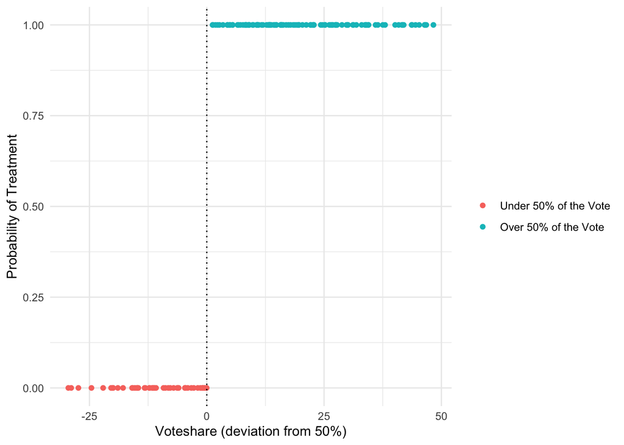

```r
ghana <- read.csv("Ghana_RD.csv") # loading data

#lets Start off with

#checking if voteshare < 50 indicates always treatment of 1 and vice versa
  #ghana_t2 <- ghana %>%
  #  filter(treatment == 1)
  #  summary(ghana_t2$voteshare) #works

  #ghana_t3 <- ghana %>%
  #  filter(treatment == 0)
  #  summary(ghana_t3$voteshare) #works

#centering around 0
ghana$voteshare_centered <- ghana$voteshare - 50


#potentially additional way to check if the voteshare = treamtment
ggplot(ghana, aes(x = voteshare_centered ,
                 y = treatment,
                 color = factor(treatment))) +
  geom_point() +
  labs(x = "Voteshare (deviation from 50%)",
       y = "Probability of Treatment") +
  scale_color_discrete(name = " ",
                       labels = c("Under 50% of the Vote", "Over 50% of the Vote")) +
  geom_vline(xintercept = 0, linetype = "dotted") +
  theme_minimal()
```

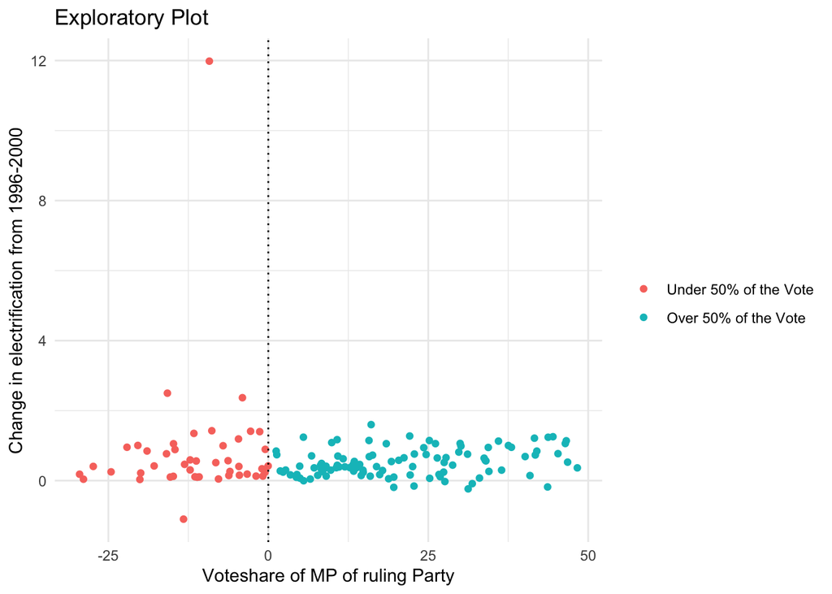

```r
#omit outlier
  #ghana_omit <- ghana %>% filter(changeNL_1996_2000 < 11)


#scatterplot
ggplot(ghana,
       aes(x = voteshare_centered, # age
           y = changeNL_1996_2000, col = factor(treatment))) +
  geom_point() +
  geom_vline(xintercept = 0, linetype = "dotted") +
  labs(title = "Exploratory Plot",
       x = "Voteshare of MP of ruling Party",
       y = "Change in electrification from 1996-2000") +
  scale_color_discrete(name = " ",
                      labels = c("Under 50% of the Vote", "Over 50% of the Vote")) +
  theme_minimal()
```

Yes, it does make sense to employ a sharp RD in this case because the treatment status (0 or 1) is all cases clearly determined by the forcing variable which is the vote share centered around 50%.

The visual check shows that the probability of treatment is always 0 if the voteshare is under 50% and the probability of treatment is always 1 if the voteshare is over 50%. Moreover, we can see that many observations are cluster just before and just after the threshold, which makes it possible to employ a sharp RD.

2. Choose a bandwidth that seems reasonable to you, cut down the dataset to the discontinuity sample, and then estimate the LATE at the threshold using a linear model with common slopes for treated and control units within the bandwidth. Provide a plot in which you show the fitted curves and the underlying scatterplot of the data. Interpret your estimate. [4 pts]

```r
#bandwith 40%-60% -> centered: -10%-10%

#create discontinuity sample
ghana_dSample <- ghana %>%
  filter(voteshare_centered  < 10)%>%
  filter(voteshare_centered  > -10)

#check if it worked
  #summary(ghana_dSample$voteshare_centered)

# running linear model with common slope
linear_common_slope <- lm(changeNL_1996_2000 ~ treatment + voteshare_centered, data = ghana_dSample)
summary(linear_common_slope)
```

```
##
## Call:
## lm(formula = changeNL_1996_2000 ~ treatment + voteshare_centered,
##     data = ghana_dSample)
##
## Residuals:
##     Min      1Q  Median      3Q     Max
## -1.7197 -0.6489 -0.3071  0.3686  9.9807
##
## Coefficients:
##                    Estimate Std. Error t value Pr(>|t|)
## (Intercept)         0.48266    0.50237   0.961   0.3419
## treatment           0.89616    1.00223   0.894   0.3761
## voteshare_centered -0.16493    0.08638  -1.909   0.0628 .
## ---
## Signif. codes:  0 '***' 0.001 '**' 0.01 '*' 0.05 '.' 0.1 ' ' 1
##
## Residual standard error: 1.668 on 44 degrees of freedom
## Multiple R-squared:  0.1231, Adjusted R-squared:  0.0832
## F-statistic: 3.087 on 2 and 44 DF,  p-value: 0.05563
```

```r
#LATE =  0.89616

print("With a chosen bandwith of 40%-60%, alias -10%-10%, the LATE of a linear model with common slopes is 0.89616 (statistically not significant).")
```

```
## [1] "With a chosen bandwith of 40%-60%, alias -10%-10%, the LATE of a linear model with common slopes is 0.89616 (statistically not significant)."
```

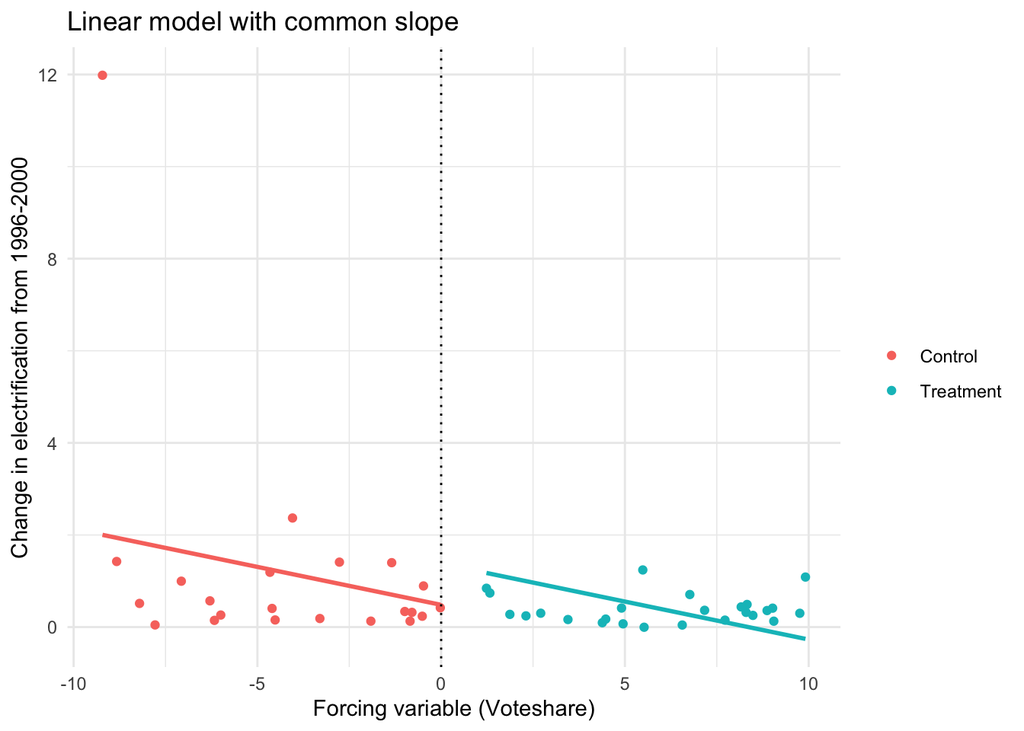

```r
#drawing the graph
 ghana_dSample$electricity_linear <- predict(linear_common_slope)

linear_plot <- ghana_dSample %>%
  ggplot(aes(x = voteshare_centered,
             y = electricity_linear,
             col = factor(treatment))) +
  geom_point(aes(x = voteshare_centered,
                 y = changeNL_1996_2000,
                 col = factor(treatment))) +
  labs(title = "Linear model with common slope",
       x = "Forcing variable (Voteshare)",
       y = "Change in electrification from 1996-2000") +
  geom_line(data = ghana_dSample[ghana_dSample$voteshare_centered >= 0,],
            color = "#00BFC4",
            size = 1) +
  geom_line(data = ghana_dSample[ghana_dSample$voteshare_centered < 0,],
            color = "#F8766D",
            size = 1) +
  scale_color_manual(name = "",
                     values = c("#F8766D", "#00BFC4"),
                     labels = c("Control", "Treatment")) +
  geom_vline(xintercept = 0, linetype = "dotted") +
  theme_minimal()

linear_plot
```

Bandwidth: 40-60 percent (centered: -10%-10%). Due to the limited number of observations, I chose the bandwith bigger that what would be ideal. There is a tradeoff between statistical significane and biased results.

The LATE (0.89616) tells us, that the change in electrification from 1996-2000 was locally around the cutoff on average 0.89616 percentage points higher in constituencies where a member of the ruling party became MP ((got slightly over 50% of the vote) compared to constituencies where the member of the ruling party became slightly less than 50% (and therefore lost the election). The LATE is highly depentend on the chosen bandwidth and can even the direction of the effect can change if the bandwidth is changed.

3. Conduct the same analysis as in part (b) except that you now use a quadratic model with different model coefficients for the treated and control groups! [2 pts]

```r
quadratic <- lm(changeNL_1996_2000 ~ voteshare_centered +
                  I(voteshare_centered^2) + # I tells R to interpret "as is"
                  treatment +
                  I(voteshare_centered * treatment) +
                  I((voteshare_centered^2) * treatment),
                data = ghana_dSample)
summary(quadratic)
```

```
##
## Call:
## lm(formula = changeNL_1996_2000 ~ voteshare_centered + I(voteshare_centered^2) +
##     treatment + I(voteshare_centered * treatment) + I((voteshare_centered^2) *
##     treatment), data = ghana_dSample)
##
## Residuals:
##     Min      1Q  Median      3Q     Max
## -2.7964 -0.2955 -0.1030  0.1600  7.1358
##
## Coefficients:
##                                       Estimate Std. Error t value Pr(>|t|)
## (Intercept)                            1.32682    0.72421   1.832  0.07421
## voteshare_centered                     0.91266    0.40854   2.234  0.03100
## I(voteshare_centered^2)                0.14048    0.04477   3.138  0.00315
## treatment                             -0.53246    1.52424  -0.349  0.72863
## I(voteshare_centered * treatment)     -1.10522    0.67881  -1.628  0.11115
## I((voteshare_centered^2) * treatment) -0.12329    0.06524  -1.890  0.06588
##
## (Intercept)                           .
## voteshare_centered                    *
## I(voteshare_centered^2)               **
## treatment
## I(voteshare_centered * treatment)
## I((voteshare_centered^2) * treatment) .
## ---
## Signif. codes:  0 '***' 0.001 '**' 0.01 '*' 0.05 '.' 0.1 ' ' 1
##
## Residual standard error: 1.487 on 41 degrees of freedom
## Multiple R-squared:  0.351,  Adjusted R-squared:  0.2718
## F-statistic: 4.434 on 5 and 41 DF,  p-value: 0.002549
```

```r
print("With a chosen bandwith of 40%-60%, alias -10%-10%, the LATE of a non-linear model (quadratic model) is -0.53246 (statistically not significant).")
```

```
## [1] "With a chosen bandwith of 40%-60%, alias -10%-10%, the LATE of a non-linear model (quadratic model) is -0.53246 (statistically not significant)."
```

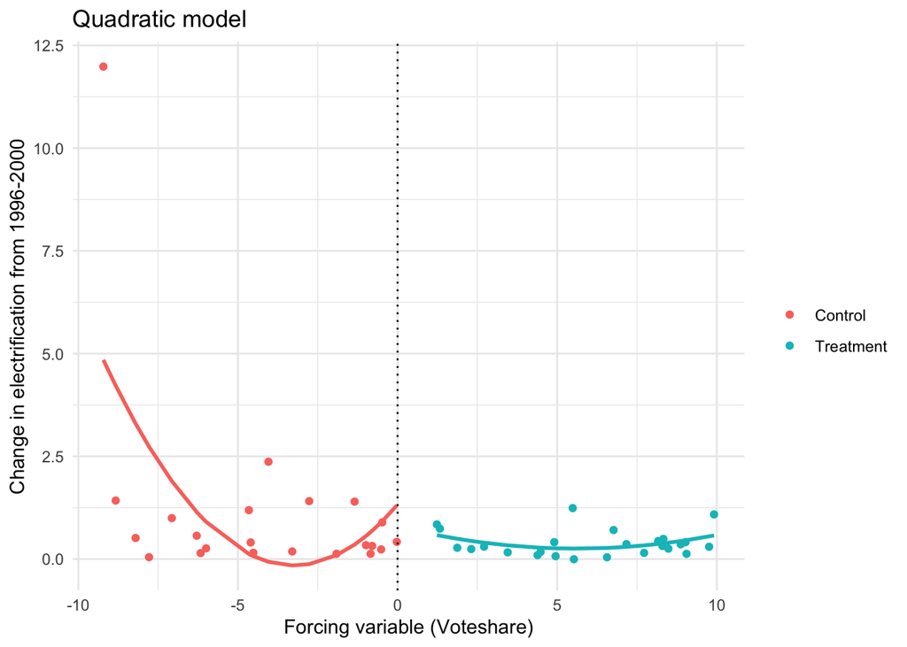

```r
ghana_dSample$electricity_quadratic <- predict(quadratic)

quadratic_plot <- ghana_dSample %>%
  ggplot(aes(x = voteshare_centered,
             y = electricity_quadratic,
             col = factor(treatment))) +
  geom_point(aes(x = voteshare_centered,
                 y = changeNL_1996_2000,
                 col = factor(treatment))) +
  labs(title = "Quadratic model",
       x = "Forcing variable (Voteshare)",
       y = "Change in electrification from 1996-2000") +
  geom_line(data = ghana_dSample[ghana_dSample$voteshare_centered >= 0,],
            color = "#00BFC4",
            size = 1) +
  geom_line(data = ghana_dSample[ghana_dSample$voteshare_centered < 0,],
            color = "#F8766D",
            size = 1) +
  scale_color_manual(name = "",
                     values = c("#F8766D", "#00BFC4"),
                     labels = c("Control", "Treatment")) +
  geom_vline(xintercept = 0, linetype = "dotted") +
  theme_minimal()

quadratic_plot
```

Interpretation: The LATE (-0.53246) of this quadratic model tells us, that the change in electrification from 1996-2000 was locally around the cutoff on average 0.53246 percentage points lower in constituencies where a member of the ruling party became MP ((got slightly over 50% of the vote) compared to constituencies where the member of the ruling party became slightly less than 50% (and therefore lost the election). This differs greatlyfrom the results of the linear model with common slopes. A possible explanation is that the quadratic model is overfitting the data.

4. Now estimate the LATE at the threshold using a local linear regression with a triangular kernel. Also, use the Imbens-Kalyanamaran optimal bandwidth calculation. [3 pts]

```r
linear_kernel <- RDestimate(changeNL_1996_2000 ~ voteshare_centered, cutpoint = 0, kernel = "triangular", data = ghana_dSample)
summary(linear_kernel)
```

```
##
## Call:
## RDestimate(formula = changeNL_1996_2000 ~ voteshare_centered,
##     data = ghana_dSample, cutpoint = 0, kernel = "triangular")
##
## Type:
## sharp
##
## Estimates:
##            Bandwidth  Observations  Estimate  Std. Error  z value
## LATE       3.324      15            0.9944    0.2461      4.0403
## Half-BW    1.662       9            1.8013    0.1910      9.4292
## Double-BW  6.648      30            0.2553    0.2609      0.9784
##            Pr(>|z|)
## LATE       5.339e-05  ***
## Half-BW    4.132e-21  ***
## Double-BW  3.279e-01
## ---
## Signif. codes:  0 '***' 0.001 '**' 0.01 '*' 0.05 '.' 0.1 ' ' 1
##
## F-statistics:
##            F       Num. DoF  Denom. DoF  p
## LATE       0.7357  3         11          0.8955
## Half-BW    0.2254  3          5          0.2500
## Double-BW  1.1967  3         26          0.6610
```

```r
print("The LATE using a local linear regression is: 0.9944")
```

```
## [1] "The LATE using a local linear regression is: 0.9944"
```

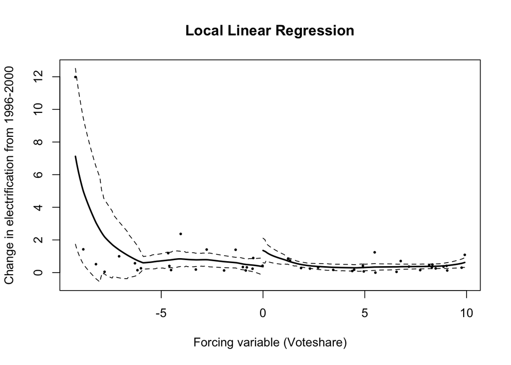

```r
plot(linear_kernel)
title(main = "Local Linear Regression", xlab = "Forcing variable (Voteshare)",ylab = "Change in electrification from 1996-2000")
```

5. Going over the estimation results again, how robust are they to different specifications of the regression? What other types of robustness checks might be appropriate? [2 pts]

The results are not robust to differenct specifications of the regression. Depending on which specifications is used, the magnitude and the direction of the effect are changing. For exmaple, if a linear regression is used, the change in electricity in a constituency where an MP of the ruling party won is positive (0.89616), while it is negative if we use a quadratic regression (-0.53246). As the results of a linear model with common slope and of a local linear regression are pretty close, we can assume that the effect is likely to be positive and in the range of 0.8-1.0.

Linear model with common slopes: 0.89616 Quadratic model: -0.53246 Local linear regression: 0.9944

Other types of robustness checks (via falsification checks): (1. Sensitivity: Are results sensitive to alternative specifications?) 2. Balance checks: Does any covariate Zi jump at the threshold? 3. Do jumps occur at placebo thresholds c∗? 4. Sorting: Do units sort around the threshold?